# final_project

Gáldi Borbála

2024-12-14

# Load the required packages

```r
library(tidyverse)
library(car)
library(skimr)
```

# Import the dataset

```r
english_education <- readr::read_csv('https://raw.githubusercontent.com/rfordatascience/tidytuesday/main/data/2024/2024-01-23/english_education.csv')
```

# Inspect the data

```r
glimpse(english_education)
```

```
## Rows: 1,104
## Columns: 31
## $ town11cd                                                          <chr> "E34…
## $ town11nm                                                          <chr> "Car…
## $ population_2011                                                   <dbl> 5456…
## $ size_flag                                                         <chr> "Sma…
## $ rgn11nm                                                           <chr> "Eas…
## $ coastal                                                           <chr> "Non…
## $ coastal_detailed                                                  <chr> "Sma…
## $ ttwa11cd                                                          <chr> "E30…
## $ ttwa11nm                                                          <chr> "Wor…
## $ ttwa_classification                                               <chr> "Maj…
## $ job_density_flag                                                  <chr> "Res…
## $ income_flag                                                       <chr> "Hig…
## $ university_flag                                                   <chr> "No …
```

[output cut: 18 more lines]

```r
str(english_education)
```

```
## spc_tbl_ [1,104 × 31] (S3: spec_tbl_df/tbl_df/tbl/data.frame)
##  $ town11cd                                                         : chr [1:1104] "E34000007" "E34000016" "E34000020" "E34000026" ...
##  $ town11nm                                                         : chr [1:1104] "Carlton in Lindrick BUA" "Dorchester (West Dorset) BUA" "Ely BUA" "Market Weighton BUA" ...
##  $ population_2011                                                  : num [1:1104] 5456 19060 19090 6429 10884 ...
##  $ size_flag                                                        : chr [1:1104] "Small Towns" "Small Towns" "Small Towns" "Small Towns" ...
##  $ rgn11nm                                                          : chr [1:1104] "East Midlands" "South West" "East of England" "Yorkshire and The Humber" ...
##  $ coastal                                                          : chr [1:1104] "Non-coastal" "Non-coastal" "Non-coastal" "Non-coastal" ...
##  $ coastal_detailed                                                 : chr [1:1104] "Smaller non-coastal town" "Smaller non-coastal town" "Smaller non-coastal town" "Smaller non-coastal town" ...
##  $ ttwa11cd                                                         : chr [1:1104] "E30000291" "E30000046" "E30000186" "E30000220" ...
##  $ ttwa11nm                                                         : chr [1:1104] "Worksop and Retford" "Dorchester and Weymouth" "Cambridge" "Hull" ...
##  $ ttwa_classification                                              : chr [1:1104] "Majority town and city (small)" "Majority town and city (small)" "Majority town and city (Large Towns)" "Majority town and city (Large Towns)" ...
##  $ job_density_flag                                                 : chr [1:1104] "Residential" "Working" "Working" "Residential" ...
##  $ income_flag                                                      : chr [1:1104] "Higher deprivation towns" "Mid deprivation towns" "Lower deprivation towns" "Lower deprivation towns" ...
##  $ university_flag                                                  : chr [1:1104] "No university" "No university" "No university" "No university" ...
##  $ level4qual_residents35_64_2011                                   : chr [1:1104] "Low" "Medium" "Medium" "Medium" ...
##  $ ks4_2012_2013_counts                                             : num [1:1104] 65 239 155 58 93 158 118 235 92 169 ...
##  $ key_stage_2_attainment_school_year_2007_to_2008                  : num [1:1104] 65 69.1 71.4 71 78 ...
##  $ key_stage_4_attainment_school_year_2012_to_2013                  : num [1:1104] 70.8 71.1 56.1 53.4 62.4 ...
##  $ level_2_at_age_18                                                : num [1:1104] 72.3 85.7 83.9 91.2 78.5 ...
##  $ level_3_at_age_18                                                : num [1:1104] 50.8 60.1 45.8 49.1 40.9 ...
##  $ activity_at_age_19_full_time_higher_education                    : num [1:1104] 30.8 41.8 35.5 25.9 26.9 ...
##  $ activity_at_age_19_sustained_further_education                   : num [1:1104] 21.5 13.4 11 25.9 20.4 ...
##  $ activity_at_age_19_appprenticeships                              : num [1:1104] NA 10.04 7.74 NA 15.05 ...
##  $ activity_at_age_19_employment_with_earnings_above_0              : num [1:1104] 52.3 51 57.4 58.6 55.9 ...
##  $ activity_at_age_19_employment_with_earnings_above_10_000         : num [1:1104] 36.9 24.7 27.7 31 30.1 ...
##  $ activity_at_age_19_out_of_work                                   : num [1:1104] NA 4.18 NA NA 15.05 ...
##  $ highest_level_qualification_achieved_by_age_22_less_than_level_1 : num [1:1104] NA NA NA NA NA NA NA NA NA NA ...
##  $ highest_level_qualification_achieved_by_age_22_level_1_to_level_2: num [1:1104] 34.9 21.7 34.4 NA 32.6 29.4 34.5 37.8 19.6 23.7 ...
##  $ highest_level_qualification_achieved_by_age_22_level_3_to_level_5: num [1:1104] 39.7 44.6 31.2 66.1 44.2 40 47.9 37.8 47.8 50.9 ...
##  $ highest_level_qualification_achieved_by_age_22_level_6_or_above  : num [1:1104] NA 33.3 32.5 NA NA 28.1 NA 23.6 32.6 23.7 ...
##  $ highest_level_qualification_achieved_b_age_22_average_score      : num [1:1104] 3.32 3.73 3.55 3.48 3.16 ...
##  $ education_score                                                  : num [1:1104] -0.534 1.952 -1.044 -1.249 -1.169 ...
##  - attr(*, "spec")=
##   .. cols(
##   ..   town11cd = col_character(),
##   ..   town11nm = col_character(),
##   ..   population_2011 = col_double(),
##   ..   size_flag = col_character(),
##   ..   rgn11nm = col_character(),
##   ..   coastal = col_character(),
```

[output cut: 12 more lines]

```
##   ..   level_3_at_age_18 = col_double(),
##   ..   activity_at_age_19_full_time_higher_education = col_double(),
##   ..   activity_at_age_19_sustained_further_education = col_double(),
##   ..   activity_at_age_19_appprenticeships = col_double(),
##   ..   activity_at_age_19_employment_with_earnings_above_0 = col_double(),
##   ..   activity_at_age_19_employment_with_earnings_above_10_000 = col_double(),
##   ..   activity_at_age_19_out_of_work = col_double(),
##   ..   highest_level_qualification_achieved_by_age_22_less_than_level_1 = col_double(),
##   ..   highest_level_qualification_achieved_by_age_22_level_1_to_level_2 = col_double(),
##   ..   highest_level_qualification_achieved_by_age_22_level_3_to_level_5 = col_double(),
##   ..   highest_level_qualification_achieved_by_age_22_level_6_or_above = col_double(),
##   ..   highest_level_qualification_achieved_b_age_22_average_score = col_double(),
##   ..   education_score = col_double()
##   .. )
##  - attr(*, "problems")=<externalptr>
```

```r
summary(english_education)
```

```
##    town11cd           town11nm         population_2011    size_flag
##  Length:1104        Length:1104        Min.   :   5003   Length:1104
##  Class :character   Class :character   1st Qu.:   8076   Class :character
##  Mode  :character   Mode  :character   Median :  15436   Mode  :character
##                                        Mean   :  33347
##                                        3rd Qu.:  32722
##                                        Max.   :1085810
##                                        NA's   :4
##    rgn11nm            coastal          coastal_detailed     ttwa11cd
##  Length:1104        Length:1104        Length:1104        Length:1104
##  Class :character   Class :character   Class :character   Class :character
##  Mode  :character   Mode  :character   Mode  :character   Mode  :character
##
##
##
##
##    ttwa11nm         ttwa_classification job_density_flag   income_flag
##  Length:1104        Length:1104         Length:1104        Length:1104
##  Class :character   Class :character    Class :character   Class :character
##  Mode  :character   Mode  :character    Mode  :character   Mode  :character
##
##
##
##
##  university_flag    level4qual_residents35_64_2011 ks4_2012_2013_counts
##  Length:1104        Length:1104                    Min.   :   14.0
##  Class :character   Class :character               1st Qu.:   92.0
##  Mode  :character   Mode  :character               Median :  172.5
##                                                    Mean   :  511.6
##                                                    3rd Qu.:  374.2
##                                                    Max.   :59743.0
##
##  key_stage_2_attainment_school_year_2007_to_2008
##  Min.   :28.09
##  1st Qu.:68.69
##  Median :74.21
##  Mean   :74.07
##  3rd Qu.:80.02
##  Max.   :98.63
##
```

[output cut: 81 more lines]

```
##  Min.   :12.10
##  1st Qu.:23.50
##  Median :28.00
##  Mean   :29.55
##  3rd Qu.:34.60
##  Max.   :61.40
##  NA's   :231
##  highest_level_qualification_achieved_b_age_22_average_score education_score
##  Min.   :2.567                                               Min.   :-10.0280
##  1st Qu.:3.264                                               1st Qu.: -2.5707
##  Median :3.479                                               Median : -0.2824
##  Mean   :3.514                                               Mean   :  0.0000
##  3rd Qu.:3.725                                               3rd Qu.:  2.2265
##  Max.   :5.143                                               Max.   : 11.8715
##
```

```r
skim(english_education)
```

Data summary

| Name | english_education |
| --- | --- |
| Number of rows | 1104 |
| Number of columns | 31 |
| _______________________ |  |
| Column type frequency: |  |
| character | 13 |
| numeric | 18 |
| ________________________ |  |
| Group variables | None |

**Variable type: character**

| skim_variable | n_missing | complete_rate | min | max | empty | n_unique | whitespace |
| --- | --- | --- | --- | --- | --- | --- | --- |
| town11cd | 4 | 1 | 9 | 9 | 0 | 1100 | 0 |
| town11nm | 0 | 1 | 7 | 41 | 0 | 1104 | 0 |
| size_flag | 0 | 1 | 4 | 16 | 0 | 8 | 0 |
| rgn11nm | 2 | 1 | 6 | 24 | 0 | 9 | 0 |
| coastal | 4 | 1 | 7 | 11 | 0 | 2 | 0 |
| coastal_detailed | 4 | 1 | 6 | 26 | 0 | 7 | 0 |
| ttwa11cd | 4 | 1 | 9 | 9 | 0 | 154 | 0 |
| ttwa11nm | 4 | 1 | 4 | 32 | 0 | 154 | 0 |
| ttwa_classification | 4 | 1 | 14 | 36 | 0 | 4 | 0 |
| job_density_flag | 4 | 1 | 5 | 11 | 0 | 3 | 0 |
| income_flag | 4 | 1 | 6 | 24 | 0 | 4 | 0 |
| university_flag | 4 | 1 | 10 | 13 | 0 | 2 | 0 |
| level4qual_residents35_64_2011 | 4 | 1 | 3 | 6 | 0 | 3 | 0 |

**Variable type: numeric**

| skim_variable | n_missing | complete_rate | mean | sd | p0 | p25 | p50 | p75 | p100 | hist |
| --- | --- | --- | --- | --- | --- | --- | --- | --- | --- | --- |
| population_2011 | 4 | 1.00 | 33346.63 | 62499.84 | 5003.00 | 8076.00 | 15436.00 | 32721.75 | 1085810.00 | ▇▁▁▁▁ |
| ks4_2012_2013_counts | 0 | 1.00 | 511.56 | 2667.69 | 14.00 | 92.00 | 172.50 | 374.25 | 59743.00 | ▇▁▁▁▁ |
| key_stage_2_attainment_school_year_2007_to_2008 | 0 | 1.00 | 74.07 | 8.51 | 28.09 | 68.69 | 74.21 | 80.02 | 98.63 | ▁▁▅▇▂ |
| key_stage_4_attainment_school_year_2012_to_2013 | 0 | 1.00 | 61.30 | 10.11 | 33.33 | 54.41 | 60.85 | 67.61 | 92.86 | ▁▆▇▃▁ |
| level_2_at_age_18 | 0 | 1.00 | 83.62 | 6.65 | 56.00 | 79.40 | 83.65 | 88.40 | 99.35 | ▁▁▆▇▃ |
| level_3_at_age_18 | 0 | 1.00 | 49.39 | 11.17 | 16.54 | 41.41 | 48.52 | 56.74 | 85.71 | ▁▆▇▃▁ |
| activity_at_age_19_full_time_higher_education | 1 | 1.00 | 33.53 | 10.44 | 7.87 | 26.32 | 32.39 | 39.44 | 73.45 | ▂▇▅▂▁ |
| activity_at_age_19_sustained_further_education | 58 | 0.95 | 20.77 | 5.53 | 7.35 | 17.16 | 20.37 | 23.91 | 47.56 | ▂▇▃▁▁ |
| activity_at_age_19_appprenticeships | 195 | 0.82 | 13.66 | 4.42 | 3.00 | 10.71 | 13.13 | 16.15 | 39.02 | ▂▇▂▁▁ |
| activity_at_age_19_employment_with_earnings_above_0 | 1 | 1.00 | 49.25 | 6.78 | 28.96 | 44.63 | 49.29 | 53.78 | 71.43 | ▁▅▇▃▁ |
| activity_at_age_19_employment_with_earnings_above_10_000 | 27 | 0.98 | 24.26 | 6.19 | 7.06 | 20.00 | 23.94 | 28.07 | 48.98 | ▁▇▇▂▁ |
| activity_at_age_19_out_of_work | 462 | 0.58 | 9.86 | 4.00 | 2.27 | 6.89 | 9.29 | 12.10 | 24.64 | ▅▇▅▁▁ |
| highest_level_qualification_achieved_by_age_22_less_than_level_1 | 859 | 0.22 | 2.76 | 1.01 | 0.90 | 2.00 | 2.60 | 3.30 | 7.70 | ▆▇▂▁▁ |
| highest_level_qualification_achieved_by_age_22_level_1_to_level_2 | 48 | 0.96 | 26.73 | 7.87 | 6.50 | 21.17 | 26.40 | 31.90 | 51.70 | ▂▆▇▃▁ |
| highest_level_qualification_achieved_by_age_22_level_3_to_level_5 | 1 | 1.00 | 43.88 | 5.89 | 23.00 | 40.00 | 43.90 | 47.70 | 66.10 | ▁▃▇▂▁ |
| highest_level_qualification_achieved_by_age_22_level_6_or_above | 231 | 0.79 | 29.55 | 8.48 | 12.10 | 23.50 | 28.00 | 34.60 | 61.40 | ▃▇▅▁▁ |
| highest_level_qualification_achieved_b_age_22_average_score | 0 | 1.00 | 3.51 | 0.36 | 2.57 | 3.26 | 3.48 | 3.72 | 5.14 | ▂▇▅▁▁ |
| education_score | 0 | 1.00 | 0.00 | 3.61 | -10.03 | -2.57 | -0.28 | 2.23 | 11.87 | ▁▇▇▃▁ |

```r
tail(english_education)
```

```
## # A tibble: 6 × 31
##   town11cd  town11nm  population_2011 size_flag rgn11nm coastal coastal_detailed
##   <chr>     <chr>               <dbl> <chr>     <chr>   <chr>   <chr>
## 1 E35001517 Redditch…           81919 Large To… West M… Non-co… Large non-coast…
## 2 K06000004 Chester …           86011 Large To… North … Non-co… Large non-coast…
## 3 <NA>      Inner Lo…              NA Inner Lo… London  <NA>    <NA>
## 4 <NA>      Outer lo…              NA Outer lo… London  <NA>    <NA>
## 5 <NA>      Other Sm…              NA Other Sm… <NA>    <NA>    <NA>
## 6 <NA>      Not BUA                NA Not BUA   <NA>    <NA>    <NA>
## # ℹ 24 more variables: ttwa11cd <chr>, ttwa11nm <chr>,
## #   ttwa_classification <chr>, job_density_flag <chr>, income_flag <chr>,
## #   university_flag <chr>, level4qual_residents35_64_2011 <chr>,
## #   ks4_2012_2013_counts <dbl>,
## #   key_stage_2_attainment_school_year_2007_to_2008 <dbl>,
## #   key_stage_4_attainment_school_year_2012_to_2013 <dbl>,
## #   level_2_at_age_18 <dbl>, level_3_at_age_18 <dbl>, …
```

```r
english_education %>%
  arrange(education_score) %>%
  tail()
```

```
## # A tibble: 6 × 31
##   town11cd  town11nm  population_2011 size_flag rgn11nm coastal coastal_detailed
##   <chr>     <chr>               <dbl> <chr>     <chr>   <chr>   <chr>
## 1 E35001500 Burley i…            7041 Small To… Yorksh… Non-co… Smaller non-coa…
## 2 E34000567 Gerrards…           20633 Medium T… South … Non-co… Large non-coast…
## 3 E34002528 Olney BUA            6477 Small To… South … Non-co… Smaller non-coa…
## 4 E34002105 East Hor…            5866 Small To… South … Non-co… Smaller non-coa…
## 5 E34003511 Harpende…           30240 Medium T… East o… Non-co… Large non-coast…
## 6 E35000485 Northwoo…            5253 Small To… East o… Non-co… Smaller non-coa…
## # ℹ 24 more variables: ttwa11cd <chr>, ttwa11nm <chr>,
## #   ttwa_classification <chr>, job_density_flag <chr>, income_flag <chr>,
## #   university_flag <chr>, level4qual_residents35_64_2011 <chr>,
## #   ks4_2012_2013_counts <dbl>,
## #   key_stage_2_attainment_school_year_2007_to_2008 <dbl>,
## #   key_stage_4_attainment_school_year_2012_to_2013 <dbl>,
## #   level_2_at_age_18 <dbl>, level_3_at_age_18 <dbl>, …
```

# Exploratory data analysis:demographics and regions

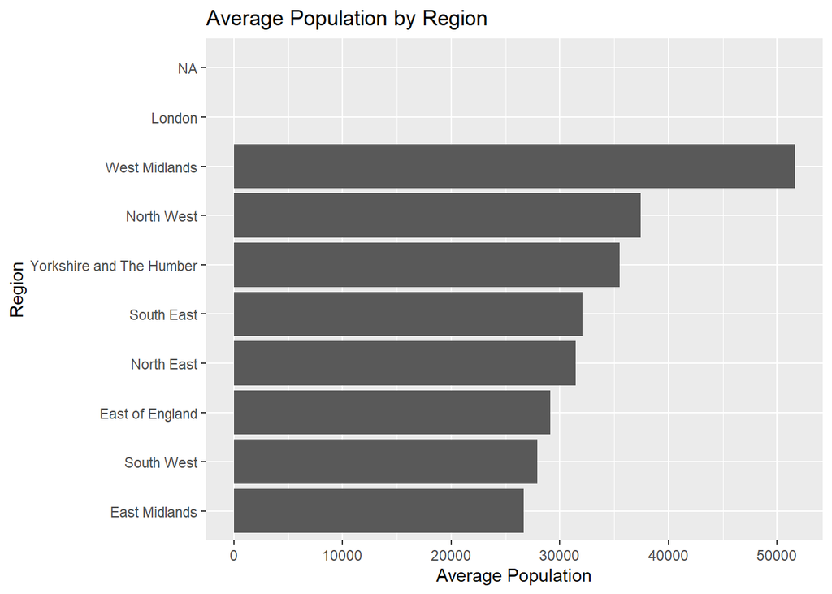

```r
english_education %>%
    group_by(rgn11nm) %>%
    summarise(mean_population = mean(population_2011, na.rm = TRUE)) %>%
    ggplot(aes(x = reorder(rgn11nm, mean_population), y = mean_population)) +
    geom_col() +
    coord_flip() +
    labs(title = "Average Population by Region", x = "Region", y = "Average Population")
```

# Barplot: size

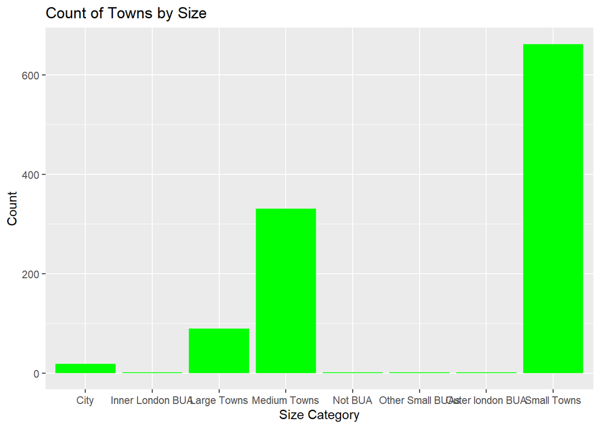

```r
ggplot(english_education, aes(x = size_flag)) +
  geom_bar(fill = "green") +
  labs(title = "Count of Towns by Size", x = "Size Category", y = "Count")
```

# Barplot: coastal

[figure not shown]

```r
ggplot(english_education, aes(x = coastal)) +
  geom_bar(fill = "blue") +
  labs(title = "Count of Towns by Size", x = "Size Category", y = "Count")
```

# Plot coastal and non-coastal mean education score

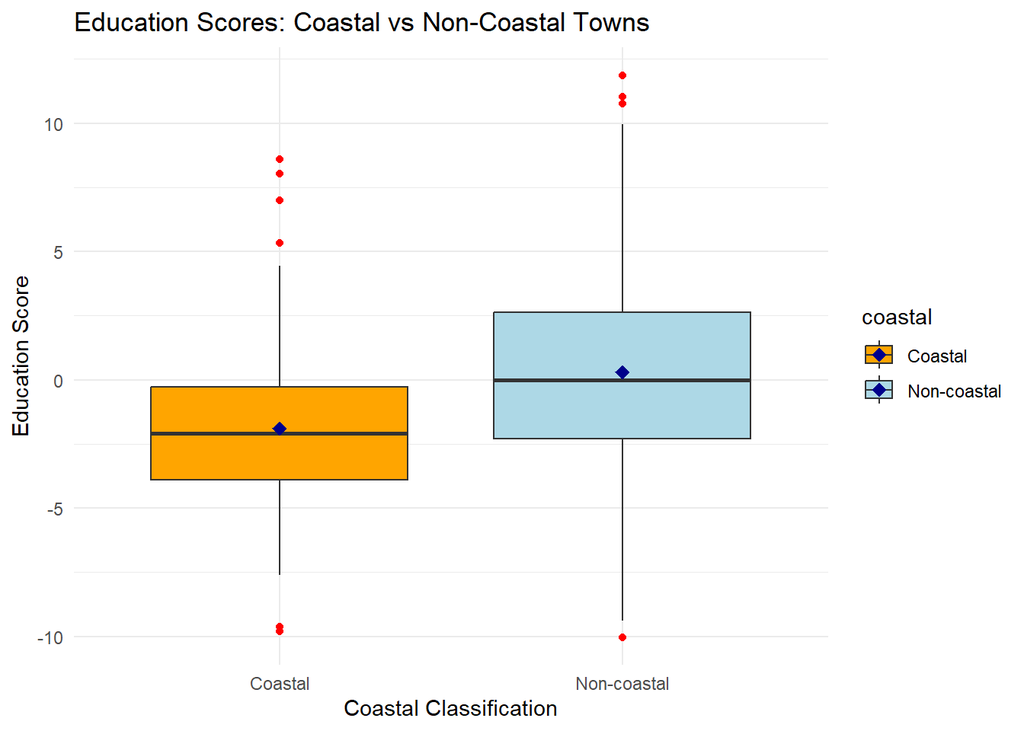

```r
ggplot(english_education %>% filter(!is.na(coastal) & !is.na(education_score)),
       aes(x = coastal, y = education_score, fill = coastal)) +
  geom_boxplot(outlier.color = "red", outlier.shape = 16) +
  stat_summary(fun = mean, geom = "point", shape = 18, size = 3, color = "darkblue") +
  labs(title = "Education Scores: Coastal vs Non-Coastal Towns",
       x = "Coastal Classification",
       y = "Education Score") +
  theme_minimal() +
  scale_fill_manual(values = c("orange", "lightblue"))
```

# Explore the variables: education score, population_2011, university_flag

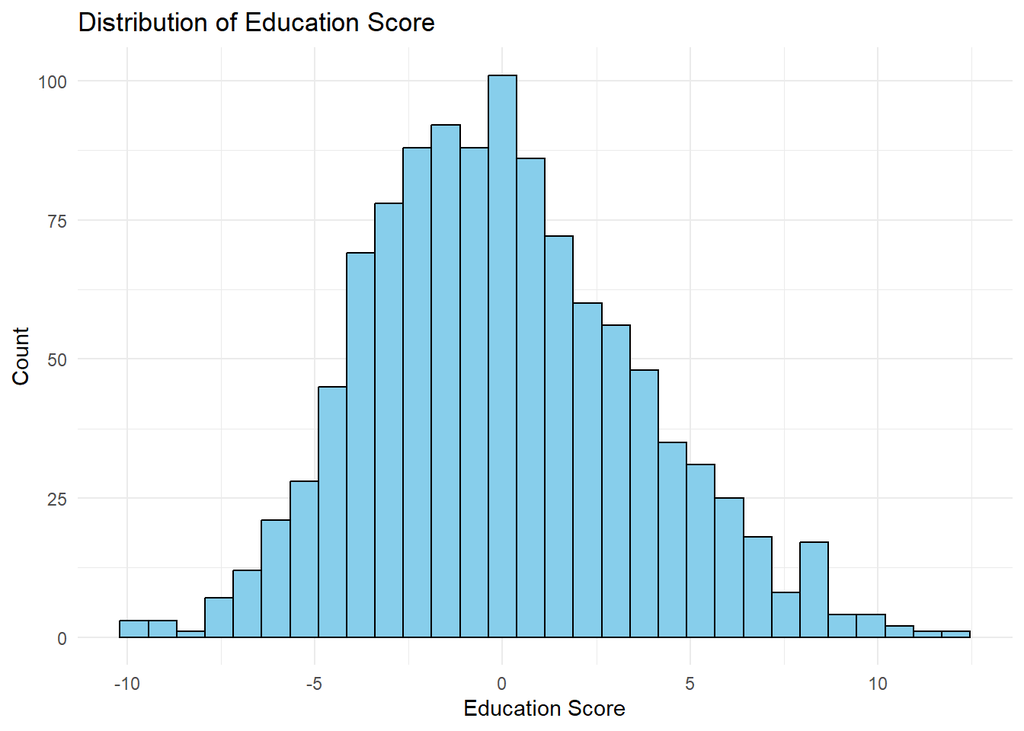

```r
# Distribution of education_score

ggplot(english_education, aes(x = education_score)) +
  geom_histogram(bins = 30, fill = "skyblue", color = "black") +
  labs(title = "Distribution of Education Score", x = "Education Score", y = "Count") +
  theme_minimal()
```

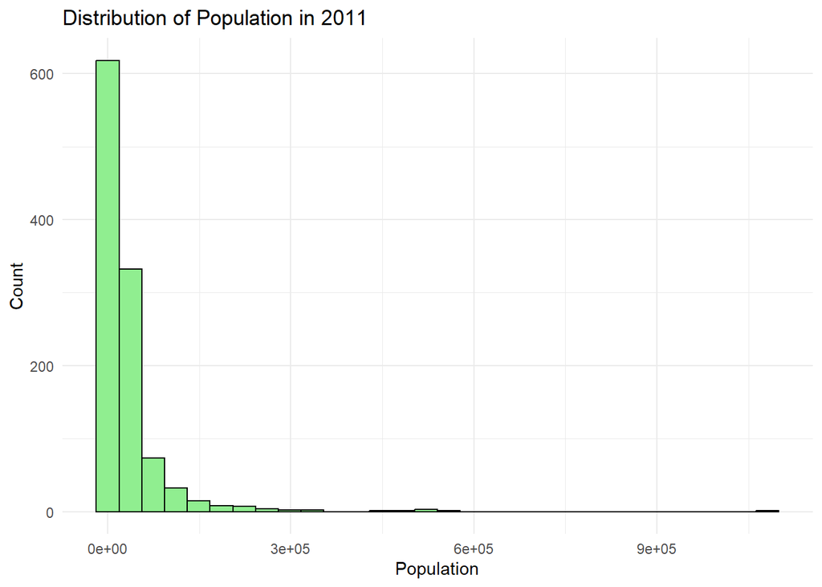

```r
# Distribution of population_2011

ggplot(english_education, aes(x = population_2011)) +
  geom_histogram(bins = 30, fill = "lightgreen", color = "black") +
  labs(title = "Distribution of Population in 2011", x = "Population", y = "Count") +
  theme_minimal()
```

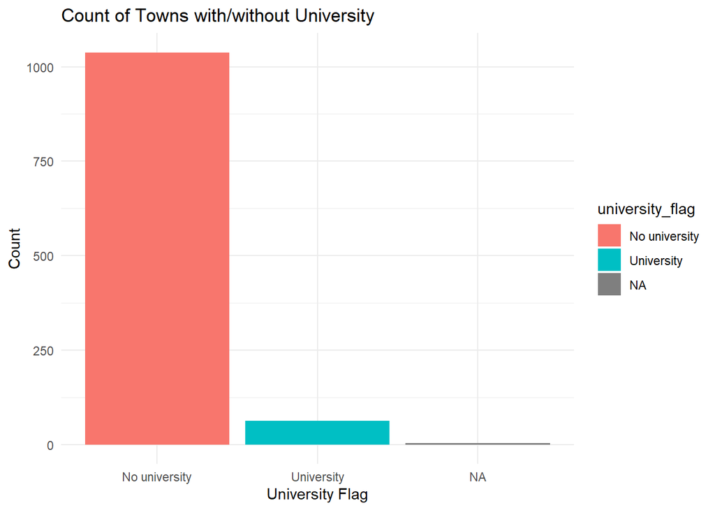

```r
# Bar plot for university_flag (No University vs University)

ggplot(english_education, aes(x = university_flag, fill = university_flag)) +
  geom_bar() +
  labs(title = "Count of Towns with/without University", x = "University Flag", y = "Count") +
  theme_minimal()
```

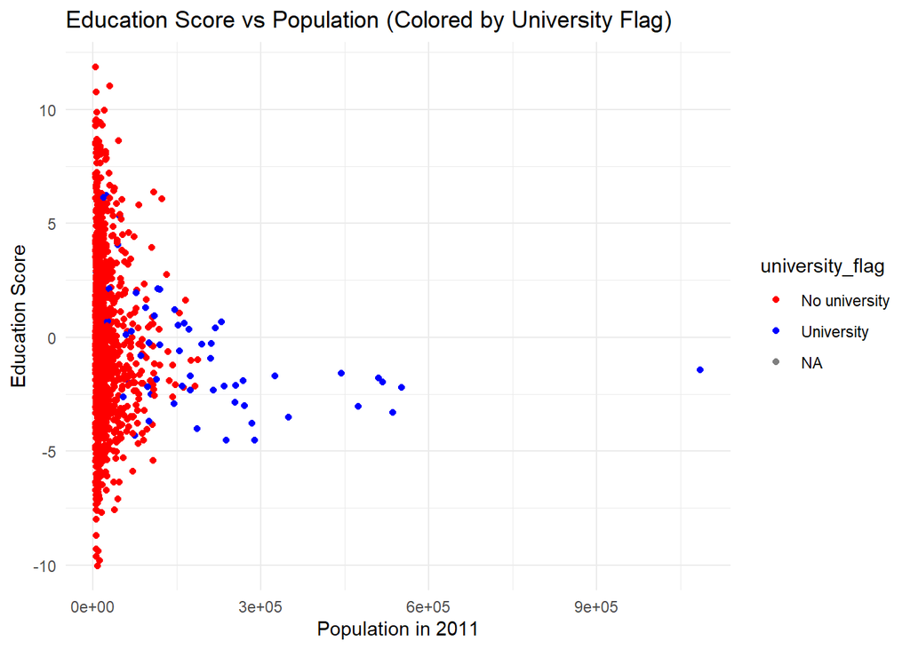

```r
# Scatter plot for education_score vs population_2011, colored by university_flag

ggplot(english_education, aes(x = population_2011, y = education_score, color = university_flag)) +
  geom_point() +
  labs(title = "Education Score vs Population (Colored by University Flag)",
       x = "Population in 2011", y = "Education Score") +
  theme_minimal() +
  scale_color_manual(values = c("No university" = "red", "University" = "blue"))
```

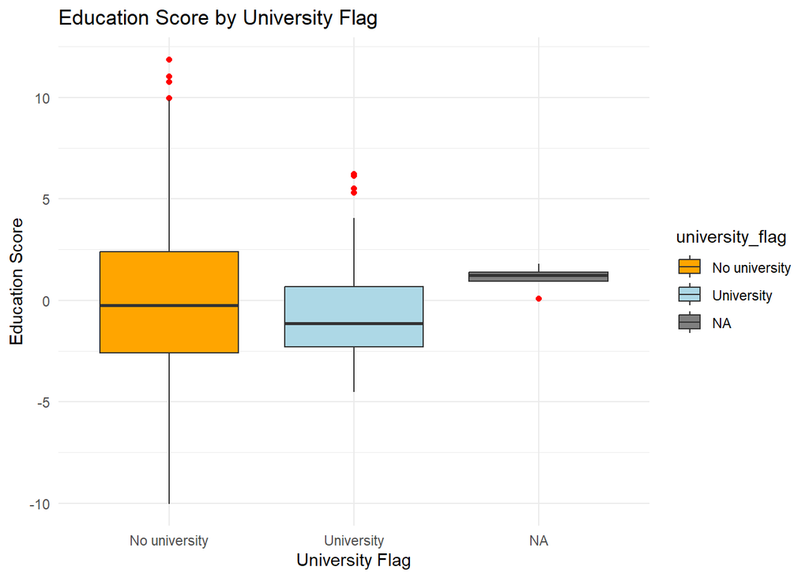

```r
# Boxplot for education_score by university_flag

ggplot(english_education, aes(x = university_flag, y = education_score, fill = university_flag)) +
  geom_boxplot(outlier.color = "red", outlier.shape = 16) +
  labs(title = "Education Score by University Flag", x = "University Flag", y = "Education Score") +
  theme_minimal() +
  scale_fill_manual(values = c("No university" = "orange", "University" = "lightblue"))
```

# Hypothesis testing:

## H1 Higher population leads to better education scores.

## H2 Having a university in a town/city leads to better education scores.

## H3 There is an interaction between population size and university presence, where a smaller town with a university might have better education scores than a larger town without a university.

```r
# Dummy code the 'university_flag' variable

english_education$university_flag <- factor(english_education$university_flag, levels = c("No university", "University"))

english_education$university_dummy <- ifelse(english_education$university_flag == "University", 1, 0)


# Build the linear regression model

model <- lm(education_score ~ population_2011 + university_dummy + population_2011 * university_dummy, data = english_education)

summary(model)
```

```
##
## Call:
## lm(formula = education_score ~ population_2011 + university_dummy +
##     population_2011 * university_dummy, data = english_education)
##
## Residuals:
##     Min      1Q  Median      3Q     Max
## -10.271  -2.573  -0.209   2.255  11.581
##
## Coefficients:
##                                    Estimate Std. Error t value Pr(>|t|)
## (Intercept)                       3.639e-01  1.515e-01   2.402  0.01648 *
## population_2011                  -1.396e-05  4.260e-06  -3.278  0.00108 **
## university_dummy                  3.396e-01  6.771e-01   0.502  0.61611
## population_2011:university_dummy  7.412e-06  4.957e-06   1.495  0.13514
## ---
## Signif. codes:  0 '***' 0.001 '**' 0.01 '*' 0.05 '.' 0.1 ' ' 1
##
## Residual standard error: 3.591 on 1096 degrees of freedom
##   (4 observations deleted due to missingness)
## Multiple R-squared:  0.01689,    Adjusted R-squared:  0.0142
## F-statistic: 6.278 on 3 and 1096 DF,  p-value: 0.0003181
```

The linear regression model shows that population size has a significant negative relationship with education scores (Estimate = -1.396e-05, p = 0.00108). However, the university presence (university_dummy) is not significant (Estimate = 0.3396, p = 0.61611), and the interaction between population size and university presence is also not significant (Estimate = 7.412e-06, p = 0.13514). The model’s R-squared value is 0.01689, indicating a weak fit. The residual standard error is 3.591, with a significant F-statistic (p = 0.0003181).

# Check the assumtions of the model

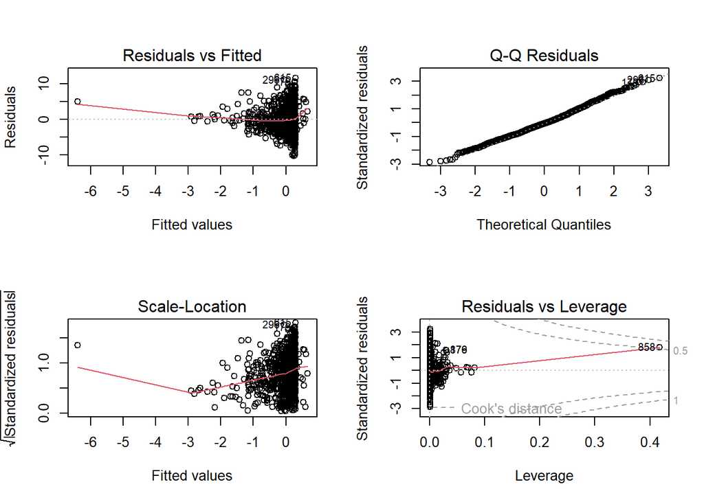

```r
# Check residuals for normality, linearity, homoscedascity

par(mfrow = c(2, 2))

plot(model)
```

```r
#Check for multicollinearity

vif(model)
```

```
## there are higher-order terms (interactions) in this model
## consider setting type = 'predictor'; see ?vif
```

```
##                  population_2011                 university_dummy
##                         6.044041                         2.080300
## population_2011:university_dummy
##                         7.775796
```

Linearity and homoscedascity assumptions are not met.

# Identify and clean out influential points with cook’s distance

```r
cooks_distance <- cooks.distance(model)

influential_points <- which(cooks_distance > (4 / length(cooks_distance)))

influential_points
```

```
##   88  176  383  446  452  528  588  614  615  858  868  872  879  939  943  953
##   88  176  383  446  452  528  588  614  615  858  868  872  879  939  943  953
##  963  967  993 1008 1020 1059
##  963  967  993 1008 1020 1059
```

```r
cooks_distance[influential_points]
```

```
##          88         176         383         446         452         528
## 0.015451324 0.019680999 0.007559369 0.012755952 0.006268907 0.007217282
##         588         614         615         858         868         872
## 0.003954351 0.012502753 0.003816989 0.588831064 0.004864749 0.004493696
##         879         939         943         953         963         967
## 0.019361227 0.016345423 0.003885903 0.005178820 0.004654230 0.004740500
##         993        1008        1020        1059
## 0.004235867 0.019335017 0.009372109 0.005602608
```

```r
cleaned_data <- english_education[-influential_points, ]
```

# Build the new model

```r
new_model <- lm(education_score ~ population_2011 + university_dummy + population_2011 * university_dummy, data = cleaned_data)

summary(new_model)
```

```
##
## Call:
## lm(formula = education_score ~ population_2011 + university_dummy +
##     population_2011 * university_dummy, data = cleaned_data)
##
## Residuals:
##      Min       1Q   Median       3Q      Max
## -10.2967  -2.4773  -0.1323   2.1926  11.1670
##
## Coefficients:
##                                    Estimate Std. Error t value Pr(>|t|)
## (Intercept)                       4.311e-01  1.520e-01   2.836  0.00466 **
## population_2011                  -1.870e-05  4.475e-06  -4.178 3.18e-05 ***
## university_dummy                  4.342e-02  8.655e-01   0.050  0.96000
## population_2011:university_dummy  1.189e-05  5.711e-06   2.082  0.03758 *
## ---
## Signif. codes:  0 '***' 0.001 '**' 0.01 '*' 0.05 '.' 0.1 ' ' 1
##
## Residual standard error: 3.542 on 1074 degrees of freedom
##   (4 observations deleted due to missingness)
## Multiple R-squared:  0.02161,    Adjusted R-squared:  0.01888
## F-statistic: 7.908 on 3 and 1074 DF,  p-value: 3.21e-05
```

# Check the assumptions witht the new model

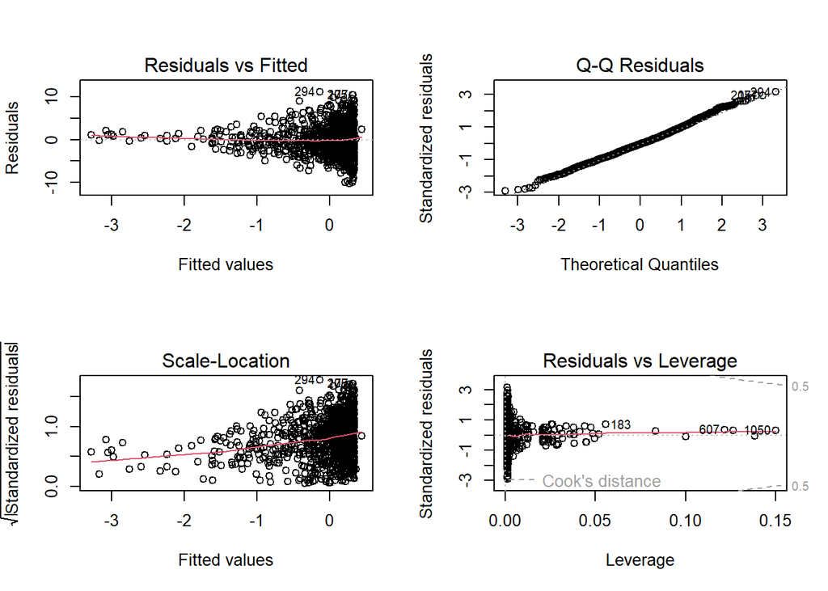

```r
# Check residuals for normality, linearity, homoscedascity

par(mfrow = c(2, 2))

plot(new_model)
```

```r
#Check for multicollinearity

vif(new_model)
```

```
## there are higher-order terms (interactions) in this model
## consider setting type = 'predictor'; see ?vif
```

```
##                  population_2011                 university_dummy
##                         4.741732                         2.791996
## population_2011:university_dummy
##                         7.125603
```

linearity and homoscedascity assumptions are still not met

Lets see these hypothesis only in case of “small towns’.

# Small Towns: hypothesis testing

```r
small_towns <- english_education %>% filter(size_flag == "Small Towns")

small_towns$university_flag <- factor(small_towns$university_flag, levels = c("No university", "University"))

small_towns$university_dummy <- ifelse(small_towns$university_flag == "University", 1, 0)

model_small_towns <- lm(education_score ~ population_2011 + university_dummy + population_2011 * university_dummy, data = small_towns)


summary(model_small_towns)
```

```
##
## Call:
## lm(formula = education_score ~ population_2011 + university_dummy +
##     population_2011 * university_dummy, data = small_towns)
##
## Residuals:
##      Min       1Q   Median       3Q      Max
## -10.4049  -2.6994  -0.1255   2.7076  11.2883
##
## Coefficients:
##                                    Estimate Std. Error t value Pr(>|t|)
## (Intercept)                       8.990e-01  3.901e-01   2.305   0.0215 *
## population_2011                  -6.011e-05  3.466e-05  -1.734   0.0834 .
## university_dummy                  1.581e+00  5.466e+00   0.289   0.7724
## population_2011:university_dummy  1.580e-04  3.827e-04   0.413   0.6797
## ---
## Signif. codes:  0 '***' 0.001 '**' 0.01 '*' 0.05 '.' 0.1 ' ' 1
##
## Residual standard error: 3.877 on 658 degrees of freedom
## Multiple R-squared:  0.009543,   Adjusted R-squared:  0.005027
## F-statistic: 2.113 on 3 and 658 DF,  p-value: 0.09729
```

# Check assumptions

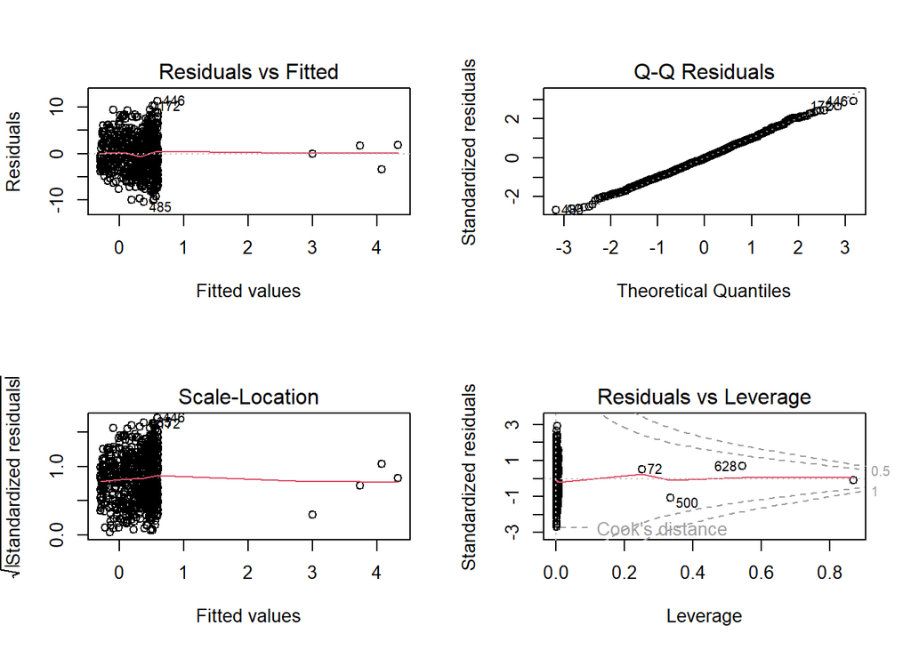

```r
# Check residuals for normality, linearity, homoscedascity

par(mfrow = c(2, 2))

plot(model_small_towns)
```

```r
#Check for multicollinearity

vif(model_small_towns)
```

```
## there are higher-order terms (interactions) in this model
## consider setting type = 'predictor'; see ?vif
```

```
##                  population_2011                 university_dummy
##                         1.011122                         7.900413
## population_2011:university_dummy
##                         7.931280
```

# Identify influential cases in the model for small town

```r
cooks_distance <- cooks.distance(model_small_towns)

influential_points_small <- which(cooks_distance > (4 / length(cooks_distance)))

cleaned_data_small <- small_towns[-influential_points_small, ]
```

# Build the new model for small towns

```r
new_model_small <- lm(education_score ~ population_2011 + university_dummy + population_2011 * university_dummy, data = cleaned_data_small)

summary(new_model_small)
```

```
##
## Call:
## lm(formula = education_score ~ population_2011 + university_dummy +
##     population_2011 * university_dummy, data = cleaned_data_small)
##
## Residuals:
##      Min       1Q   Median       3Q      Max
## -10.3734  -2.6750  -0.1129   2.7298  10.2713
##
## Coefficients: (2 not defined because of singularities)
##                                    Estimate Std. Error t value Pr(>|t|)
## (Intercept)                       8.683e-01  3.875e-01   2.241   0.0254 *
## population_2011                  -6.018e-05  3.444e-05  -1.747   0.0810 .
## university_dummy                         NA         NA      NA       NA
## population_2011:university_dummy         NA         NA      NA       NA
## ---
## Signif. codes:  0 '***' 0.001 '**' 0.01 '*' 0.05 '.' 0.1 ' ' 1
##
## Residual standard error: 3.843 on 654 degrees of freedom
## Multiple R-squared:  0.004647,   Adjusted R-squared:  0.003125
## F-statistic: 3.053 on 1 and 654 DF,  p-value: 0.08104
```